## Generative Adversarial Network (GAN)

# The material presented in this jupyter notebook is part of the "ECE 685: Introduction to Deep Learning" course offered at Duke University.

# Session: Fall 2023

# Part 10: Generative Models - b

[figure not shown]

In the vanilla-GAN we have,

- G(z): Generated image using the noise z. The images generated are called "fake samples".
- D(x): Probability of image being real, $0 \leq D(x) \leq 1$.
  - Discriminator tries to increase D(x) and decrease D(G(z)).
  - Generator tries to increase D(G(z)).

Discriminator optimization criterion:

$$\max_D \mathbb{E}_{x \sim p(x)} \log(D(x)) + \mathbb{E}_{z \sim p(z)} \log{(1-D(G(z)))}$$

Generator optimization criterion:

$$ \max_{G} \mathbb{E}_{z \sim p(z)} \log{(D(G(z)))}$$

### Reading Material: Please see Lecture Notes 16

**Generative Adversarial Networks**, introduced by Ian Goodfellow in 2014, are neural nets we can train to produce new images (or other kinds of data) that look as though they came from our true data distribution. In this notebook, we'll implement a small GAN for generating images that look as though they come from the MNIST dataset.The key insight behind the GAN is to pit two neural networks against each other. On the one hand is the Generator, a neural network that takes random noise as input and produces an image as output. On the other hand is the Discriminator, which takes in an image and classifies it as real (from MNIST) or fake (from our Generator). During training, we alternate between training the Generator to fool the Discriminator, and training the Discriminator to call the Generator's bluff.Implementing a GAN in Pytorch will give you practice turning more involved models into working code.

with special acknowledgement from https://github.com/eriklindernoren/PyTorch-GAN#gan

## Imports

```python
%matplotlib inline
import argparse
import os
import numpy as np
import math
import matplotlib.pyplot as plt

import torchvision.transforms as transforms
from torchvision.utils import save_image
from torchvision import datasets
from torchvision.utils import make_grid

from torch.utils.data import DataLoader
from torch.autograd import Variable
import torch.nn as nn
import torch.nn.functional as F
import torch
```

## Loading the data, MNIST

```python
os.makedirs("images", exist_ok=True)

n_epochs = 200 # number of epochs of training
batch_size = 64 # size of the batches
n_cpu = 8 # number of cpu threads to use during batch generation

# Adam parameters
lr = 0.0002 # adam: learning rate
b1 = 0.5 # adam: decay of first order momentum of gradient
b2 = 0.999 # adam: decay of first order momentum of gradient

latent_dim = 100 # dimensionality of the latent space
img_size = 28 # size of each image dimension
channels = 1 # number of image channels
sample_interval = 500 # interval betwen image samples
img_shape = (channels, img_size, img_size)

cuda = True if torch.cuda.is_available() else False
```

## Generator

```python
class Generator(nn.Module):
    def __init__(self):
        super(Generator, self).__init__()

        def block(in_feat, out_feat, normalize=True):
            layers = [nn.Linear(in_feat, out_feat)]
            if normalize:
                layers.append(nn.BatchNorm1d(out_feat, 0.8))
            layers.append(nn.LeakyReLU(0.2, inplace=True))
            return layers

        self.model = nn.Sequential(
            *block(latent_dim, 128, normalize=False),
            *block(128, 256),
            *block(256, 512),
            *block(512, 1024),
            nn.Linear(1024, int(np.prod(img_shape))),
            nn.Tanh()
        )

    def forward(self, z):
        img = self.model(z)
        img = img.view(img.size(0), *img_shape)
        return img
```

## Discriminator

```python
class Discriminator(nn.Module):
    def __init__(self):
        super(Discriminator, self).__init__()

        self.model = nn.Sequential(
            nn.Linear(int(np.prod(img_shape)), 512),
            nn.LeakyReLU(0.2, inplace=True),
            nn.Linear(512, 256),
            nn.LeakyReLU(0.2, inplace=True),
            nn.Linear(256, 1),
            nn.Sigmoid(),
        )

    def forward(self, img):
        img_flat = img.view(img.size(0), -1)
        validity = self.model(img_flat)

        return validity
```

## Training a GAN

```
Downloading http://yann.lecun.com/exdb/mnist/train-images-idx3-ubyte.gz
Downloading http://yann.lecun.com/exdb/mnist/train-images-idx3-ubyte.gz to ./data/MNIST/raw/train-images-idx3-ubyte.gz
```

```
Extracting ./data/MNIST/raw/train-images-idx3-ubyte.gz to ./data/MNIST/raw

Downloading http://yann.lecun.com/exdb/mnist/train-labels-idx1-ubyte.gz
Downloading http://yann.lecun.com/exdb/mnist/train-labels-idx1-ubyte.gz to ./data/MNIST/raw/train-labels-idx1-ubyte.gz
```

```
Extracting ./data/MNIST/raw/train-labels-idx1-ubyte.gz to ./data/MNIST/raw

Downloading http://yann.lecun.com/exdb/mnist/t10k-images-idx3-ubyte.gz
Downloading http://yann.lecun.com/exdb/mnist/t10k-images-idx3-ubyte.gz to ./data/MNIST/raw/t10k-images-idx3-ubyte.gz
```

```
Extracting ./data/MNIST/raw/t10k-images-idx3-ubyte.gz to ./data/MNIST/raw

Downloading http://yann.lecun.com/exdb/mnist/t10k-labels-idx1-ubyte.gz
Downloading http://yann.lecun.com/exdb/mnist/t10k-labels-idx1-ubyte.gz to ./data/MNIST/raw/t10k-labels-idx1-ubyte.gz
```

```
Extracting ./data/MNIST/raw/t10k-labels-idx1-ubyte.gz to ./data/MNIST/raw
```

```
[Epoch 0/200] [Batch 0/938] [D loss: 1.398396] [G loss: 0.718168]
[Epoch 0/200] [Batch 500/938] [D loss: 0.860285] [G loss: 0.740838]
[Epoch 1/200] [Batch 62/938] [D loss: 0.676914] [G loss: 1.619740]
[Epoch 1/200] [Batch 562/938] [D loss: 0.979952] [G loss: 2.382960]
[Epoch 2/200] [Batch 124/938] [D loss: 0.848190] [G loss: 1.023766]
[Epoch 2/200] [Batch 624/938] [D loss: 1.082736] [G loss: 3.772223]
[Epoch 3/200] [Batch 186/938] [D loss: 0.536565] [G loss: 1.342136]
[Epoch 3/200] [Batch 686/938] [D loss: 0.599441] [G loss: 1.369882]
[Epoch 4/200] [Batch 248/938] [D loss: 0.335633] [G loss: 1.653102]
[Epoch 4/200] [Batch 748/938] [D loss: 0.421150] [G loss: 1.749815]
[Epoch 5/200] [Batch 310/938] [D loss: 0.440011] [G loss: 1.933613]
[Epoch 5/200] [Batch 810/938] [D loss: 0.405252] [G loss: 1.332154]
[Epoch 6/200] [Batch 372/938] [D loss: 0.413343] [G loss: 1.820485]
[Epoch 6/200] [Batch 872/938] [D loss: 0.470881] [G loss: 2.557576]
[Epoch 7/200] [Batch 434/938] [D loss: 0.852351] [G loss: 4.171337]
[Epoch 7/200] [Batch 934/938] [D loss: 0.366987] [G loss: 2.115331]
[Epoch 8/200] [Batch 496/938] [D loss: 0.370724] [G loss: 1.820434]
[Epoch 9/200] [Batch 58/938] [D loss: 0.558271] [G loss: 2.451338]
[Epoch 9/200] [Batch 558/938] [D loss: 0.360362] [G loss: 3.934175]
[Epoch 10/200] [Batch 120/938] [D loss: 0.484760] [G loss: 1.482764]
[Epoch 10/200] [Batch 620/938] [D loss: 0.316691] [G loss: 3.639652]
[Epoch 11/200] [Batch 182/938] [D loss: 0.245984] [G loss: 3.769904]
[Epoch 11/200] [Batch 682/938] [D loss: 0.834623] [G loss: 0.756701]
[Epoch 12/200] [Batch 244/938] [D loss: 0.367737] [G loss: 3.935955]
[Epoch 12/200] [Batch 744/938] [D loss: 0.373953] [G loss: 2.532100]
[Epoch 13/200] [Batch 306/938] [D loss: 0.508300] [G loss: 3.572686]
[Epoch 13/200] [Batch 806/938] [D loss: 0.556535] [G loss: 4.516364]
[Epoch 14/200] [Batch 368/938] [D loss: 0.273671] [G loss: 3.509640]
[Epoch 14/200] [Batch 868/938] [D loss: 0.469105] [G loss: 2.659152]
[Epoch 15/200] [Batch 430/938] [D loss: 0.381128] [G loss: 2.396766]
[Epoch 15/200] [Batch 930/938] [D loss: 0.368079] [G loss: 1.612107]
[Epoch 16/200] [Batch 492/938] [D loss: 0.492597] [G loss: 2.151488]
[Epoch 17/200] [Batch 54/938] [D loss: 0.624824] [G loss: 3.107169]
[Epoch 17/200] [Batch 554/938] [D loss: 0.505727] [G loss: 1.616684]
[Epoch 18/200] [Batch 116/938] [D loss: 0.648094] [G loss: 4.478505]
[Epoch 18/200] [Batch 616/938] [D loss: 0.314428] [G loss: 2.655937]
[Epoch 19/200] [Batch 178/938] [D loss: 0.183757] [G loss: 2.315065]
[Epoch 19/200] [Batch 678/938] [D loss: 0.395250] [G loss: 2.437666]
[Epoch 20/200] [Batch 240/938] [D loss: 0.250939] [G loss: 4.914032]
[Epoch 20/200] [Batch 740/938] [D loss: 0.135685] [G loss: 3.231269]
```

[output cut: 321 more lines]

```
[Epoch 192/200] [Batch 404/938] [D loss: 0.357021] [G loss: 3.155335]
[Epoch 192/200] [Batch 904/938] [D loss: 0.388803] [G loss: 2.918966]
[Epoch 193/200] [Batch 466/938] [D loss: 0.294767] [G loss: 3.531850]
[Epoch 194/200] [Batch 28/938] [D loss: 0.567468] [G loss: 1.359949]
[Epoch 194/200] [Batch 528/938] [D loss: 0.475198] [G loss: 3.823979]
[Epoch 195/200] [Batch 90/938] [D loss: 0.366215] [G loss: 2.999591]
[Epoch 195/200] [Batch 590/938] [D loss: 0.340684] [G loss: 2.064551]
[Epoch 196/200] [Batch 152/938] [D loss: 0.738590] [G loss: 1.103470]
[Epoch 196/200] [Batch 652/938] [D loss: 0.418241] [G loss: 2.407711]
[Epoch 197/200] [Batch 214/938] [D loss: 0.880975] [G loss: 3.401378]
[Epoch 197/200] [Batch 714/938] [D loss: 0.446162] [G loss: 2.859572]
[Epoch 198/200] [Batch 276/938] [D loss: 0.425676] [G loss: 3.927038]
[Epoch 198/200] [Batch 776/938] [D loss: 0.287654] [G loss: 1.924322]
[Epoch 199/200] [Batch 338/938] [D loss: 0.402943] [G loss: 2.491454]
[Epoch 199/200] [Batch 838/938] [D loss: 0.368540] [G loss: 2.795988]
```

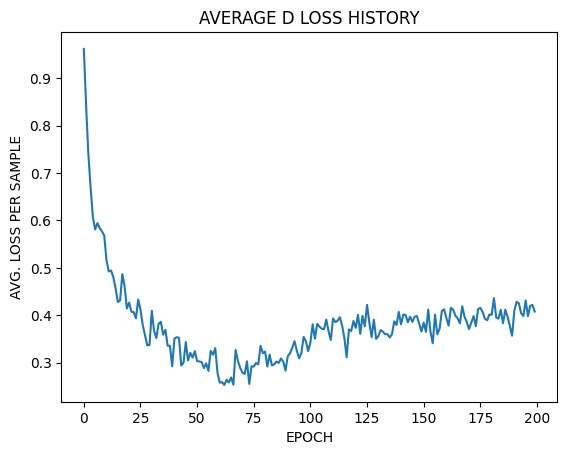

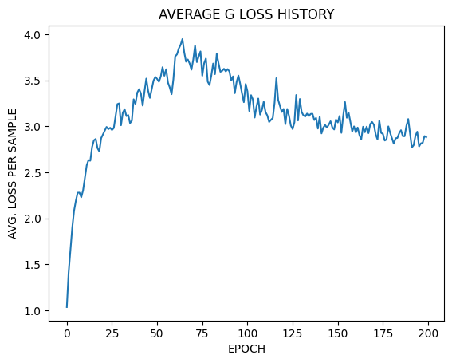

```python
# Loss function
adversarial_loss = torch.nn.BCELoss()

# Initialize generator and discriminator
generator = Generator()
discriminator = Discriminator()

if cuda:
    generator.cuda()
    discriminator.cuda()
    adversarial_loss.cuda()

# Configure data loader
os.makedirs("./data", exist_ok=True)
dataloader = torch.utils.data.DataLoader(
    datasets.MNIST(
        "./data",
        train=True,
        download=True,
        transform=transforms.Compose(
            [transforms.ToTensor(), transforms.Normalize([0.5], [0.5])]
        ),
    ),
    batch_size=batch_size,
    shuffle=True,
)

# transform: -1 <= (x - 0.5) / 0.5 <= 1

# Optimizers
optimizer_G = torch.optim.Adam(generator.parameters(), lr=lr, betas=(b1, b2))
optimizer_D = torch.optim.Adam(discriminator.parameters(), lr=lr, betas=(b1, b2))

Tensor = torch.cuda.FloatTensor if cuda else torch.FloatTensor

# ----------
#  Training
# ----------
avg_d_loss_history = []
avg_g_loss_history = []
for epoch in range(n_epochs):
    avg_d_loss = 0.
    avg_g_loss = 0.
    for i, (imgs, _) in enumerate(dataloader):

        # Adversarial ground truths
        valid = Variable(Tensor(imgs.size(0), 1).fill_(1.0), requires_grad=False)
        fake = Variable(Tensor(imgs.size(0), 1).fill_(0.0), requires_grad=False)

        # Configure input
        real_imgs = Variable(imgs.type(Tensor))

        # -----------------
        #  Train Generator
        # -----------------
        optimizer_G.zero_grad()

        # Sample noise as generator input
        z = Variable(Tensor(np.random.normal(0, 1, (imgs.shape[0], latent_dim))))

        # Generate a batch of images
        gen_imgs = generator(z)

        # Loss measures generator's ability to fool the discriminator
        g_loss = adversarial_loss(discriminator(gen_imgs), valid)

        g_loss.backward()
        optimizer_G.step()

        # ---------------------
        #  Train Discriminator
        # ---------------------
        optimizer_D.zero_grad()

        # Measure discriminator's ability to classify real from generated samples
        real_loss = adversarial_loss(discriminator(real_imgs), valid)
        fake_loss = adversarial_loss(discriminator(gen_imgs.detach()), fake)
        d_loss = (real_loss + fake_loss)

        d_loss.backward()
        optimizer_D.step()

        avg_d_loss += d_loss.item()
        avg_g_loss += g_loss.item()

        batches_done = epoch * len(dataloader) + i
        if batches_done % sample_interval == 0:
            print("[Epoch %d/%d] [Batch %d/%d] [D loss: %f] [G loss: %f]" % (epoch, n_epochs, i, len(dataloader), d_loss.item(), g_loss.item()) )
            save_image(gen_imgs.data[:25], "images/%d.png" % batches_done, nrow=5, normalize=True)

    avg_d_loss /= len(dataloader)
    avg_g_loss /= len(dataloader)
    avg_d_loss_history.append(avg_d_loss)
    avg_g_loss_history.append(avg_g_loss)


plt.plot(avg_d_loss_history)
plt.title("AVERAGE D LOSS HISTORY")
plt.xlabel("EPOCH")
plt.ylabel("AVG. LOSS PER SAMPLE")
plt.show()
plt.plot(avg_g_loss_history)
plt.title("AVERAGE G LOSS HISTORY")
plt.xlabel("EPOCH")
plt.ylabel("AVG. LOSS PER SAMPLE")
plt.show()
```

### Traning Progress

```python
with torch.no_grad():
    z = Variable(Tensor(np.random.normal(0, 1, (128, latent_dim))))
    gen_imgs = generator(z)
```

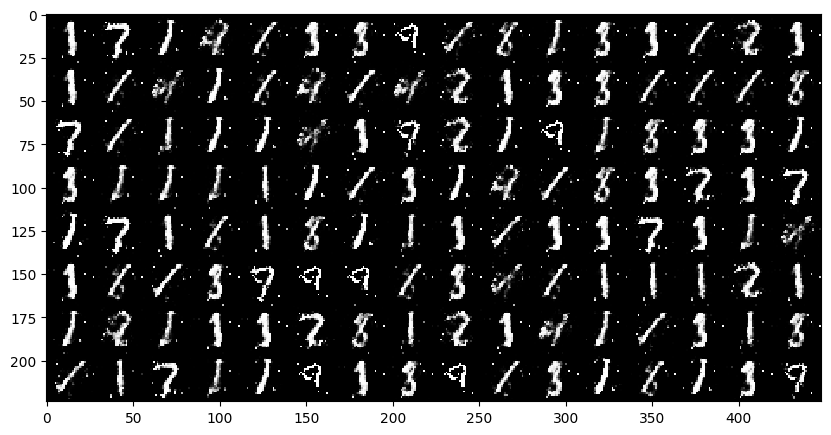

```python
img = make_grid(gen_imgs, padding=0, nrow=16)
npimg = (img.cpu().numpy() * 0.5) + 0.5

fig, axes = plt.subplots(1,1, figsize=(10,10))
axes.imshow(np.transpose(npimg, (1,2,0)), interpolation='nearest')
fig.show()
```

# Adjusting the Learning Rate, Such That G Learns Faster Than D

```python
%matplotlib inline
import argparse
import os
import numpy as np
import math
import matplotlib.pyplot as plt

import torchvision.transforms as transforms
from torchvision.utils import save_image
from torchvision import datasets
from torchvision.utils import make_grid

from torch.utils.data import DataLoader
from torch.autograd import Variable
import torch.nn as nn
import torch.nn.functional as F
import torch

os.makedirs("images", exist_ok=True)

n_epochs = 200 # number of epochs of training
batch_size = 64 # size of the batches
n_cpu = 8 # number of cpu threads to use during batch generation

# Adam parameters
lr = 0.0002 # adam: learning rate
b1 = 0.5 # adam: decay of first order momentum of gradient
b2 = 0.999 # adam: decay of first order momentum of gradient

latent_dim = 100 # dimensionality of the latent space
img_size = 28 # size of each image dimension
channels = 1 # number of image channels
sample_interval = 500 # interval betwen image samples
img_shape = (channels, img_size, img_size)

cuda = True if torch.cuda.is_available() else False

class Generator(nn.Module):
    def __init__(self):
        super(Generator, self).__init__()

        def block(in_feat, out_feat, normalize=True):
            layers = [nn.Linear(in_feat, out_feat)]
            if normalize:
                layers.append(nn.BatchNorm1d(out_feat, 0.8))
            layers.append(nn.LeakyReLU(0.2, inplace=True))
            return layers

        self.model = nn.Sequential(
            *block(latent_dim, 128, normalize=False),
            *block(128, 256),
            *block(256, 512),
            *block(512, 1024),
            nn.Linear(1024, int(np.prod(img_shape))),
            nn.Tanh()
        )

    def forward(self, z):
        img = self.model(z)
        img = img.view(img.size(0), *img_shape)
        return img

class Discriminator(nn.Module):
    def __init__(self):
        super(Discriminator, self).__init__()

        self.model = nn.Sequential(
            nn.Linear(int(np.prod(img_shape)), 512),
            nn.LeakyReLU(0.2, inplace=True),
            nn.Linear(512, 256),
            nn.LeakyReLU(0.2, inplace=True),
            nn.Linear(256, 1),
            nn.Sigmoid(),
        )

    def forward(self, img):
        img_flat = img.view(img.size(0), -1)
        validity = self.model(img_flat)

        return validity

# Loss function
adversarial_loss = torch.nn.BCELoss()

# Initialize generator and discriminator
generator = Generator()
discriminator = Discriminator()

if cuda:
    generator.cuda()
    discriminator.cuda()
    adversarial_loss.cuda()

# Configure data loader
os.makedirs("./data", exist_ok=True)
dataloader = torch.utils.data.DataLoader(
    datasets.MNIST(
        "./data",
        train=True,
        download=True,
        transform=transforms.Compose(
            [transforms.ToTensor(), transforms.Normalize([0.5], [0.5])]
        ),
    ),
    batch_size=batch_size,
    shuffle=True,
)

# transform: -1 <= (x - 0.5) / 0.5 <= 1
```

```
Downloading http://yann.lecun.com/exdb/mnist/train-images-idx3-ubyte.gz
Downloading http://yann.lecun.com/exdb/mnist/train-images-idx3-ubyte.gz to ./data/MNIST/raw/train-images-idx3-ubyte.gz
```

```
Extracting ./data/MNIST/raw/train-images-idx3-ubyte.gz to ./data/MNIST/raw
```

```
Downloading http://yann.lecun.com/exdb/mnist/train-labels-idx1-ubyte.gz
Downloading http://yann.lecun.com/exdb/mnist/train-labels-idx1-ubyte.gz to ./data/MNIST/raw/train-labels-idx1-ubyte.gz
```

```
Extracting ./data/MNIST/raw/train-labels-idx1-ubyte.gz to ./data/MNIST/raw

Downloading http://yann.lecun.com/exdb/mnist/t10k-images-idx3-ubyte.gz
Downloading http://yann.lecun.com/exdb/mnist/t10k-images-idx3-ubyte.gz to ./data/MNIST/raw/t10k-images-idx3-ubyte.gz
```

```
Extracting ./data/MNIST/raw/t10k-images-idx3-ubyte.gz to ./data/MNIST/raw
```

```
Downloading http://yann.lecun.com/exdb/mnist/t10k-labels-idx1-ubyte.gz
Downloading http://yann.lecun.com/exdb/mnist/t10k-labels-idx1-ubyte.gz to ./data/MNIST/raw/t10k-labels-idx1-ubyte.gz
```

```
Extracting ./data/MNIST/raw/t10k-labels-idx1-ubyte.gz to ./data/MNIST/raw
```

```
[Epoch 0/200] [Batch 0/938] [D loss: 1.432414] [G loss: 0.669007]
[Epoch 0/200] [Batch 500/938] [D loss: 0.867296] [G loss: 1.473618]
[Epoch 1/200] [Batch 62/938] [D loss: 1.341879] [G loss: 0.684147]
[Epoch 1/200] [Batch 562/938] [D loss: 1.336034] [G loss: 0.723732]
[Epoch 2/200] [Batch 124/938] [D loss: 1.301286] [G loss: 0.548962]
[Epoch 2/200] [Batch 624/938] [D loss: 0.963087] [G loss: 1.258257]
[Epoch 3/200] [Batch 186/938] [D loss: 1.321781] [G loss: 0.811868]
[Epoch 3/200] [Batch 686/938] [D loss: 1.569678] [G loss: 0.822782]
[Epoch 4/200] [Batch 248/938] [D loss: 1.130676] [G loss: 1.276481]
[Epoch 4/200] [Batch 748/938] [D loss: 1.205917] [G loss: 1.026660]
[Epoch 5/200] [Batch 310/938] [D loss: 0.913707] [G loss: 1.264454]
[Epoch 5/200] [Batch 810/938] [D loss: 1.069094] [G loss: 1.562635]
[Epoch 6/200] [Batch 372/938] [D loss: 1.020992] [G loss: 1.400249]
[Epoch 6/200] [Batch 872/938] [D loss: 0.740390] [G loss: 1.193650]
[Epoch 7/200] [Batch 434/938] [D loss: 1.031593] [G loss: 1.014563]
[Epoch 7/200] [Batch 934/938] [D loss: 0.977190] [G loss: 1.227859]
[Epoch 8/200] [Batch 496/938] [D loss: 0.947952] [G loss: 1.217057]
[Epoch 9/200] [Batch 58/938] [D loss: 0.960965] [G loss: 1.843764]
[Epoch 9/200] [Batch 558/938] [D loss: 1.083857] [G loss: 1.573237]
[Epoch 10/200] [Batch 120/938] [D loss: 0.772493] [G loss: 1.486589]
[Epoch 10/200] [Batch 620/938] [D loss: 0.867275] [G loss: 1.922718]
[Epoch 11/200] [Batch 182/938] [D loss: 0.638187] [G loss: 1.153486]
[Epoch 11/200] [Batch 682/938] [D loss: 0.766201] [G loss: 1.484225]
[Epoch 12/200] [Batch 244/938] [D loss: 0.594997] [G loss: 1.968311]
[Epoch 12/200] [Batch 744/938] [D loss: 0.482876] [G loss: 1.749490]
[Epoch 13/200] [Batch 306/938] [D loss: 0.673064] [G loss: 1.933117]
[Epoch 13/200] [Batch 806/938] [D loss: 0.744555] [G loss: 1.333923]
[Epoch 14/200] [Batch 368/938] [D loss: 0.804448] [G loss: 2.498528]
[Epoch 14/200] [Batch 868/938] [D loss: 0.985910] [G loss: 0.924583]
[Epoch 15/200] [Batch 430/938] [D loss: 1.138233] [G loss: 2.113792]
[Epoch 15/200] [Batch 930/938] [D loss: 0.754933] [G loss: 1.919904]
[Epoch 16/200] [Batch 492/938] [D loss: 0.719333] [G loss: 1.241791]
[Epoch 17/200] [Batch 54/938] [D loss: 0.582417] [G loss: 2.759430]
[Epoch 17/200] [Batch 554/938] [D loss: 0.421801] [G loss: 3.090184]
[Epoch 18/200] [Batch 116/938] [D loss: 0.888725] [G loss: 1.805813]
[Epoch 18/200] [Batch 616/938] [D loss: 0.790383] [G loss: 1.249694]
[Epoch 19/200] [Batch 178/938] [D loss: 0.428777] [G loss: 2.084880]
[Epoch 19/200] [Batch 678/938] [D loss: 0.426303] [G loss: 1.646667]
[Epoch 20/200] [Batch 240/938] [D loss: 0.430232] [G loss: 1.988151]
[Epoch 20/200] [Batch 740/938] [D loss: 0.860761] [G loss: 2.608283]
```

[output cut: 321 more lines]

```
[Epoch 192/200] [Batch 404/938] [D loss: 0.203266] [G loss: 3.631323]
[Epoch 192/200] [Batch 904/938] [D loss: 0.421542] [G loss: 3.038266]
[Epoch 193/200] [Batch 466/938] [D loss: 0.291391] [G loss: 3.073680]
[Epoch 194/200] [Batch 28/938] [D loss: 0.326435] [G loss: 1.810378]
[Epoch 194/200] [Batch 528/938] [D loss: 0.161081] [G loss: 4.250648]
[Epoch 195/200] [Batch 90/938] [D loss: 0.365258] [G loss: 2.215162]
[Epoch 195/200] [Batch 590/938] [D loss: 0.557563] [G loss: 2.785338]
[Epoch 196/200] [Batch 152/938] [D loss: 0.142897] [G loss: 3.374013]
[Epoch 196/200] [Batch 652/938] [D loss: 0.131175] [G loss: 2.736331]
[Epoch 197/200] [Batch 214/938] [D loss: 0.222690] [G loss: 3.834836]
[Epoch 197/200] [Batch 714/938] [D loss: 0.278669] [G loss: 4.322625]
[Epoch 198/200] [Batch 276/938] [D loss: 0.370516] [G loss: 2.461409]
[Epoch 198/200] [Batch 776/938] [D loss: 0.303910] [G loss: 2.859636]
[Epoch 199/200] [Batch 338/938] [D loss: 0.751860] [G loss: 1.281028]
[Epoch 199/200] [Batch 838/938] [D loss: 0.772597] [G loss: 1.193464]
```

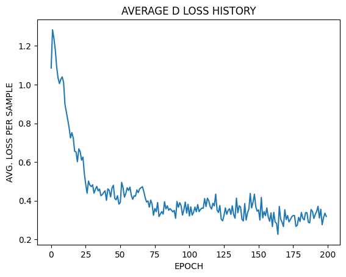

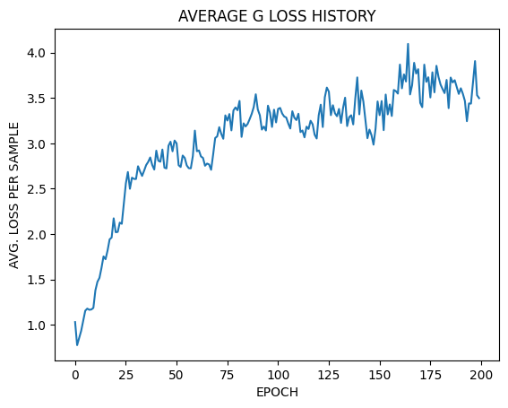

```python
# Optimizers
optimizer_G = torch.optim.Adam(generator.parameters(), lr=10.0*lr, betas=(b1, b2))
optimizer_D = torch.optim.Adam(discriminator.parameters(), lr=lr, betas=(b1, b2))

Tensor = torch.cuda.FloatTensor if cuda else torch.FloatTensor

# ----------
#  Training
# ----------
avg_d_loss_history = []
avg_g_loss_history = []
for epoch in range(n_epochs):
    avg_d_loss = 0.
    avg_g_loss = 0.
    for i, (imgs, _) in enumerate(dataloader):

        # Adversarial ground truths
        valid = Variable(Tensor(imgs.size(0), 1).fill_(1.0), requires_grad=False)
        fake = Variable(Tensor(imgs.size(0), 1).fill_(0.0), requires_grad=False)

        # Configure input
        real_imgs = Variable(imgs.type(Tensor))

        # -----------------
        #  Train Generator
        # -----------------
        optimizer_G.zero_grad()

        # Sample noise as generator input
        z = Variable(Tensor(np.random.normal(0, 1, (imgs.shape[0], latent_dim))))

        # Generate a batch of images
        gen_imgs = generator(z)

        # Loss measures generator's ability to fool the discriminator
        g_loss = adversarial_loss(discriminator(gen_imgs), valid)

        g_loss.backward()
        optimizer_G.step()

        # ---------------------
        #  Train Discriminator
        # ---------------------
        optimizer_D.zero_grad()

        # Measure discriminator's ability to classify real from generated samples
        real_loss = adversarial_loss(discriminator(real_imgs), valid)
        fake_loss = adversarial_loss(discriminator(gen_imgs.detach()), fake)
        d_loss = (real_loss + fake_loss)

        d_loss.backward()
        optimizer_D.step()

        avg_d_loss += d_loss.item()
        avg_g_loss += g_loss.item()

        batches_done = epoch * len(dataloader) + i
        if batches_done % sample_interval == 0:
            print("[Epoch %d/%d] [Batch %d/%d] [D loss: %f] [G loss: %f]" % (epoch, n_epochs, i, len(dataloader), d_loss.item(), g_loss.item()) )
            save_image(gen_imgs.data[:25], "images/%d.png" % batches_done, nrow=5, normalize=True)

    avg_d_loss /= len(dataloader)
    avg_g_loss /= len(dataloader)
    avg_d_loss_history.append(avg_d_loss)
    avg_g_loss_history.append(avg_g_loss)


plt.plot(avg_d_loss_history)
plt.title("AVERAGE D LOSS HISTORY")
plt.xlabel("EPOCH")
plt.ylabel("AVG. LOSS PER SAMPLE")
plt.show()
plt.plot(avg_g_loss_history)
plt.title("AVERAGE G LOSS HISTORY")
plt.xlabel("EPOCH")
plt.ylabel("AVG. LOSS PER SAMPLE")
plt.show()
```

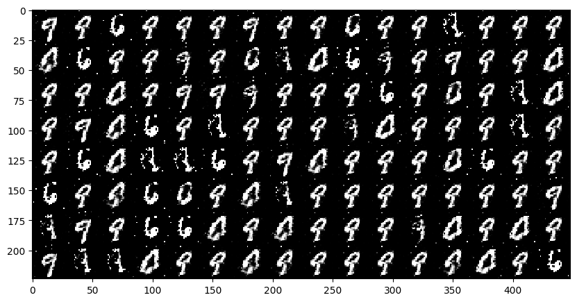

```python
with torch.no_grad():
    z = Variable(Tensor(np.random.normal(0, 1, (128, latent_dim))))
    gen_imgs = generator(z)

img = make_grid(gen_imgs, padding=0, nrow=16)
npimg = (img.cpu().numpy() * 0.5) + 0.5

fig, axes = plt.subplots(1,1, figsize=(10,10))
axes.imshow(np.transpose(npimg, (1,2,0)), interpolation='nearest')
fig.show()
```

############

```
[Epoch 0/200] [Batch 0/938] [D loss: 1.493657] [G loss: 0.708000]
[Epoch 0/200] [Batch 500/938] [D loss: 1.086696] [G loss: 0.794141]
[Epoch 1/200] [Batch 62/938] [D loss: 0.995283] [G loss: 0.934955]
[Epoch 1/200] [Batch 562/938] [D loss: 1.419796] [G loss: 0.701870]
[Epoch 2/200] [Batch 124/938] [D loss: 1.019433] [G loss: 0.810414]
[Epoch 2/200] [Batch 624/938] [D loss: 0.887103] [G loss: 0.763469]
[Epoch 3/200] [Batch 186/938] [D loss: 0.790493] [G loss: 0.981106]
[Epoch 3/200] [Batch 686/938] [D loss: 0.759053] [G loss: 1.265446]
[Epoch 4/200] [Batch 248/938] [D loss: 0.629149] [G loss: 1.285191]
[Epoch 4/200] [Batch 748/938] [D loss: 0.574256] [G loss: 1.358442]
[Epoch 5/200] [Batch 310/938] [D loss: 0.840215] [G loss: 0.858062]
[Epoch 5/200] [Batch 810/938] [D loss: 0.747336] [G loss: 2.564167]
[Epoch 6/200] [Batch 372/938] [D loss: 0.782836] [G loss: 0.841735]
[Epoch 6/200] [Batch 872/938] [D loss: 0.661845] [G loss: 1.312490]
[Epoch 7/200] [Batch 434/938] [D loss: 0.735027] [G loss: 2.053513]
[Epoch 7/200] [Batch 934/938] [D loss: 0.566340] [G loss: 2.109796]
[Epoch 8/200] [Batch 496/938] [D loss: 0.667025] [G loss: 2.676696]
[Epoch 9/200] [Batch 58/938] [D loss: 1.453691] [G loss: 4.177275]
[Epoch 9/200] [Batch 558/938] [D loss: 0.383738] [G loss: 1.725433]
[Epoch 10/200] [Batch 120/938] [D loss: 0.407383] [G loss: 2.052445]
[Epoch 10/200] [Batch 620/938] [D loss: 0.463030] [G loss: 1.516796]
[Epoch 11/200] [Batch 182/938] [D loss: 0.862966] [G loss: 4.158086]
[Epoch 11/200] [Batch 682/938] [D loss: 1.367168] [G loss: 3.987868]
[Epoch 12/200] [Batch 244/938] [D loss: 0.419108] [G loss: 1.652655]
[Epoch 12/200] [Batch 744/938] [D loss: 0.578921] [G loss: 1.561125]
[Epoch 13/200] [Batch 306/938] [D loss: 0.554913] [G loss: 1.334326]
[Epoch 13/200] [Batch 806/938] [D loss: 0.642191] [G loss: 1.453639]
[Epoch 14/200] [Batch 368/938] [D loss: 0.950458] [G loss: 0.555435]
[Epoch 14/200] [Batch 868/938] [D loss: 0.477986] [G loss: 1.399493]
[Epoch 15/200] [Batch 430/938] [D loss: 0.365566] [G loss: 2.998775]
[Epoch 15/200] [Batch 930/938] [D loss: 0.261329] [G loss: 2.108973]
[Epoch 16/200] [Batch 492/938] [D loss: 0.718276] [G loss: 2.855704]
[Epoch 17/200] [Batch 54/938] [D loss: 0.656843] [G loss: 1.434886]
[Epoch 17/200] [Batch 554/938] [D loss: 0.341207] [G loss: 2.352655]
[Epoch 18/200] [Batch 116/938] [D loss: 0.643565] [G loss: 0.940594]
[Epoch 18/200] [Batch 616/938] [D loss: 0.443451] [G loss: 1.612701]
[Epoch 19/200] [Batch 178/938] [D loss: 0.615305] [G loss: 3.628201]
[Epoch 19/200] [Batch 678/938] [D loss: 0.581732] [G loss: 3.819330]
[Epoch 20/200] [Batch 240/938] [D loss: 0.500058] [G loss: 1.780616]
[Epoch 20/200] [Batch 740/938] [D loss: 0.329592] [G loss: 2.702917]
```

[output cut: 321 more lines]

```
[Epoch 192/200] [Batch 404/938] [D loss: 0.695429] [G loss: 3.281534]
[Epoch 192/200] [Batch 904/938] [D loss: 0.310491] [G loss: 2.387318]
[Epoch 193/200] [Batch 466/938] [D loss: 0.339709] [G loss: 2.548999]
[Epoch 194/200] [Batch 28/938] [D loss: 0.355685] [G loss: 2.600507]
[Epoch 194/200] [Batch 528/938] [D loss: 0.993867] [G loss: 4.647405]
[Epoch 195/200] [Batch 90/938] [D loss: 0.536333] [G loss: 3.164808]
[Epoch 195/200] [Batch 590/938] [D loss: 0.565963] [G loss: 3.667423]
[Epoch 196/200] [Batch 152/938] [D loss: 0.368969] [G loss: 2.905248]
[Epoch 196/200] [Batch 652/938] [D loss: 0.854338] [G loss: 6.113450]
[Epoch 197/200] [Batch 214/938] [D loss: 0.589809] [G loss: 1.670732]
[Epoch 197/200] [Batch 714/938] [D loss: 0.502192] [G loss: 2.320546]
[Epoch 198/200] [Batch 276/938] [D loss: 0.528145] [G loss: 1.324033]
[Epoch 198/200] [Batch 776/938] [D loss: 0.705478] [G loss: 3.626187]
[Epoch 199/200] [Batch 338/938] [D loss: 0.302427] [G loss: 2.944135]
[Epoch 199/200] [Batch 838/938] [D loss: 0.498030] [G loss: 2.939103]
```

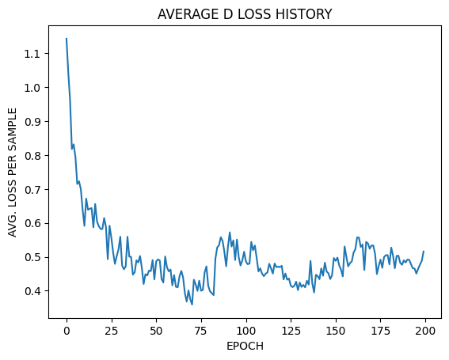

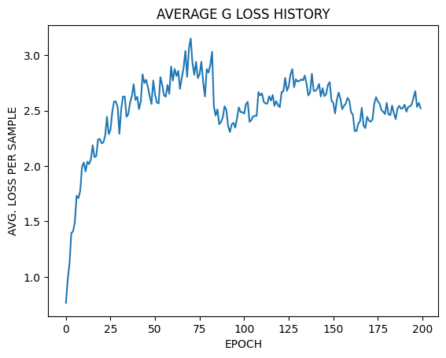

```python
# Optimizers
optimizer_G = torch.optim.Adam(generator.parameters(), lr=lr, betas=(b1, b2))
optimizer_D = torch.optim.Adam(discriminator.parameters(), lr=0.5*lr, betas=(b1, b2))

Tensor = torch.cuda.FloatTensor if cuda else torch.FloatTensor

# ----------
#  Training
# ----------
avg_d_loss_history = []
avg_g_loss_history = []
for epoch in range(n_epochs):
    avg_d_loss = 0.
    avg_g_loss = 0.
    for i, (imgs, _) in enumerate(dataloader):

        # Adversarial ground truths
        valid = Variable(Tensor(imgs.size(0), 1).fill_(1.0), requires_grad=False)
        fake = Variable(Tensor(imgs.size(0), 1).fill_(0.0), requires_grad=False)

        # Configure input
        real_imgs = Variable(imgs.type(Tensor))

        # -----------------
        #  Train Generator
        # -----------------
        optimizer_G.zero_grad()

        # Sample noise as generator input
        z = Variable(Tensor(np.random.normal(0, 1, (imgs.shape[0], latent_dim))))

        # Generate a batch of images
        gen_imgs = generator(z)

        # Loss measures generator's ability to fool the discriminator
        g_loss = adversarial_loss(discriminator(gen_imgs), valid)

        g_loss.backward()
        optimizer_G.step()

        # ---------------------
        #  Train Discriminator
        # ---------------------
        optimizer_D.zero_grad()

        # Measure discriminator's ability to classify real from generated samples
        real_loss = adversarial_loss(discriminator(real_imgs), valid)
        fake_loss = adversarial_loss(discriminator(gen_imgs.detach()), fake)
        d_loss = (real_loss + fake_loss)

        d_loss.backward()
        optimizer_D.step()

        avg_d_loss += d_loss.item()
        avg_g_loss += g_loss.item()

        batches_done = epoch * len(dataloader) + i
        if batches_done % sample_interval == 0:
            print("[Epoch %d/%d] [Batch %d/%d] [D loss: %f] [G loss: %f]" % (epoch, n_epochs, i, len(dataloader), d_loss.item(), g_loss.item()) )
            save_image(gen_imgs.data[:25], "images/%d.png" % batches_done, nrow=5, normalize=True)

    avg_d_loss /= len(dataloader)
    avg_g_loss /= len(dataloader)
    avg_d_loss_history.append(avg_d_loss)
    avg_g_loss_history.append(avg_g_loss)


plt.plot(avg_d_loss_history)
plt.title("AVERAGE D LOSS HISTORY")
plt.xlabel("EPOCH")
plt.ylabel("AVG. LOSS PER SAMPLE")
plt.show()
plt.plot(avg_g_loss_history)
plt.title("AVERAGE G LOSS HISTORY")
plt.xlabel("EPOCH")
plt.ylabel("AVG. LOSS PER SAMPLE")
plt.show()
```

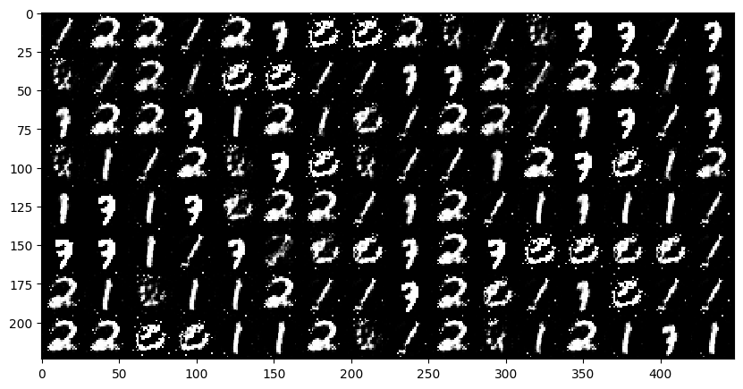

```python
with torch.no_grad():
    z = Variable(Tensor(np.random.normal(0, 1, (128, latent_dim))))
    gen_imgs = generator(z)

img = make_grid(gen_imgs, padding=0, nrow=16)
npimg = (img.cpu().numpy() * 0.5) + 0.5

fig, axes = plt.subplots(1,1, figsize=(10,10))
axes.imshow(np.transpose(npimg, (1,2,0)), interpolation='nearest')
fig.show()
```

```
[Epoch 0/200] [Batch 0/938] [D loss: 1.405730] [G loss: 0.669155]
[Epoch 0/200] [Batch 500/938] [D loss: 1.119073] [G loss: 0.834250]
[Epoch 1/200] [Batch 62/938] [D loss: 1.054621] [G loss: 0.640284]
[Epoch 1/200] [Batch 562/938] [D loss: 1.023253] [G loss: 1.134475]
[Epoch 2/200] [Batch 124/938] [D loss: 1.108100] [G loss: 1.551947]
[Epoch 2/200] [Batch 624/938] [D loss: 0.926651] [G loss: 1.514800]
[Epoch 3/200] [Batch 186/938] [D loss: 0.820711] [G loss: 1.084803]
[Epoch 3/200] [Batch 686/938] [D loss: 1.045511] [G loss: 0.866006]
[Epoch 4/200] [Batch 248/938] [D loss: 0.984722] [G loss: 1.209385]
[Epoch 4/200] [Batch 748/938] [D loss: 0.952113] [G loss: 0.967960]
[Epoch 5/200] [Batch 310/938] [D loss: 0.888629] [G loss: 1.684659]
[Epoch 5/200] [Batch 810/938] [D loss: 0.741013] [G loss: 0.927301]
[Epoch 6/200] [Batch 372/938] [D loss: 0.629408] [G loss: 1.576996]
[Epoch 6/200] [Batch 872/938] [D loss: 1.087150] [G loss: 1.576829]
[Epoch 7/200] [Batch 434/938] [D loss: 0.781523] [G loss: 1.087592]
[Epoch 7/200] [Batch 934/938] [D loss: 0.559354] [G loss: 1.861659]
[Epoch 8/200] [Batch 496/938] [D loss: 0.531880] [G loss: 1.617326]
[Epoch 9/200] [Batch 58/938] [D loss: 0.875354] [G loss: 2.171760]
[Epoch 9/200] [Batch 558/938] [D loss: 0.404737] [G loss: 2.283495]
[Epoch 10/200] [Batch 120/938] [D loss: 0.657003] [G loss: 1.097379]
[Epoch 10/200] [Batch 620/938] [D loss: 0.627030] [G loss: 2.037427]
[Epoch 11/200] [Batch 182/938] [D loss: 0.781748] [G loss: 2.142058]
[Epoch 11/200] [Batch 682/938] [D loss: 0.513061] [G loss: 2.112514]
[Epoch 12/200] [Batch 244/938] [D loss: 0.650846] [G loss: 1.249943]
[Epoch 12/200] [Batch 744/938] [D loss: 0.443341] [G loss: 1.500396]
[Epoch 13/200] [Batch 306/938] [D loss: 1.280392] [G loss: 3.867618]
[Epoch 13/200] [Batch 806/938] [D loss: 0.679890] [G loss: 1.872678]
[Epoch 14/200] [Batch 368/938] [D loss: 0.827563] [G loss: 1.383838]
[Epoch 14/200] [Batch 868/938] [D loss: 0.691557] [G loss: 1.745930]
[Epoch 15/200] [Batch 430/938] [D loss: 0.760114] [G loss: 1.229656]
[Epoch 15/200] [Batch 930/938] [D loss: 0.790006] [G loss: 1.062594]
[Epoch 16/200] [Batch 492/938] [D loss: 0.863227] [G loss: 1.565232]
[Epoch 17/200] [Batch 54/938] [D loss: 0.748180] [G loss: 1.673096]
[Epoch 17/200] [Batch 554/938] [D loss: 0.738513] [G loss: 1.442099]
[Epoch 18/200] [Batch 116/938] [D loss: 0.631401] [G loss: 1.749682]
[Epoch 18/200] [Batch 616/938] [D loss: 0.942424] [G loss: 2.466819]
[Epoch 19/200] [Batch 178/938] [D loss: 0.678599] [G loss: 1.593659]
[Epoch 19/200] [Batch 678/938] [D loss: 0.894336] [G loss: 1.011692]
[Epoch 20/200] [Batch 240/938] [D loss: 0.840624] [G loss: 1.123779]
[Epoch 20/200] [Batch 740/938] [D loss: 0.971265] [G loss: 2.159570]
```

[output cut: 321 more lines]

```
[Epoch 192/200] [Batch 404/938] [D loss: 0.609998] [G loss: 1.641344]
[Epoch 192/200] [Batch 904/938] [D loss: 0.545251] [G loss: 2.146275]
[Epoch 193/200] [Batch 466/938] [D loss: 0.532153] [G loss: 2.080575]
[Epoch 194/200] [Batch 28/938] [D loss: 0.624849] [G loss: 1.945937]
[Epoch 194/200] [Batch 528/938] [D loss: 0.518988] [G loss: 2.368438]
[Epoch 195/200] [Batch 90/938] [D loss: 0.503359] [G loss: 2.476273]
[Epoch 195/200] [Batch 590/938] [D loss: 0.766712] [G loss: 1.910062]
[Epoch 196/200] [Batch 152/938] [D loss: 0.393392] [G loss: 2.295705]
[Epoch 196/200] [Batch 652/938] [D loss: 0.637314] [G loss: 1.966154]
[Epoch 197/200] [Batch 214/938] [D loss: 0.645005] [G loss: 1.877555]
[Epoch 197/200] [Batch 714/938] [D loss: 0.522531] [G loss: 2.250682]
[Epoch 198/200] [Batch 276/938] [D loss: 0.712911] [G loss: 1.934391]
[Epoch 198/200] [Batch 776/938] [D loss: 0.516092] [G loss: 2.218429]
[Epoch 199/200] [Batch 338/938] [D loss: 0.604779] [G loss: 2.037781]
[Epoch 199/200] [Batch 838/938] [D loss: 0.345438] [G loss: 2.308815]
```

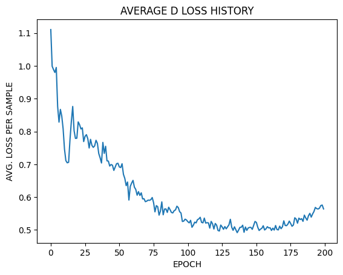

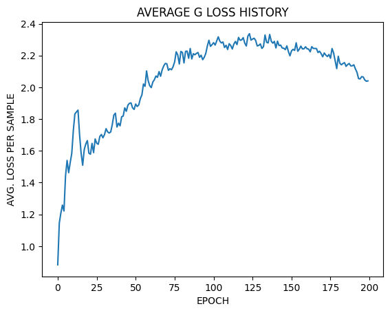

```python
# Optimizers
optimizer_G = torch.optim.Adam(generator.parameters(), lr=2.0*lr, betas=(b1, b2))
optimizer_D = torch.optim.Adam(discriminator.parameters(), lr=lr, betas=(b1, b2))

Tensor = torch.cuda.FloatTensor if cuda else torch.FloatTensor

# ----------
#  Training
# ----------
avg_d_loss_history = []
avg_g_loss_history = []
for epoch in range(n_epochs):
    avg_d_loss = 0.
    avg_g_loss = 0.
    for i, (imgs, _) in enumerate(dataloader):

        # Adversarial ground truths
        valid = Variable(Tensor(imgs.size(0), 1).fill_(1.0), requires_grad=False)
        fake = Variable(Tensor(imgs.size(0), 1).fill_(0.0), requires_grad=False)

        # Configure input
        real_imgs = Variable(imgs.type(Tensor))

        # -----------------
        #  Train Generator
        # -----------------
        optimizer_G.zero_grad()

        # Sample noise as generator input
        z = Variable(Tensor(np.random.normal(0, 1, (imgs.shape[0], latent_dim))))

        # Generate a batch of images
        gen_imgs = generator(z)

        # Loss measures generator's ability to fool the discriminator
        g_loss = adversarial_loss(discriminator(gen_imgs), valid)

        g_loss.backward()
        optimizer_G.step()

        # ---------------------
        #  Train Discriminator
        # ---------------------
        optimizer_D.zero_grad()

        # Measure discriminator's ability to classify real from generated samples
        real_loss = adversarial_loss(discriminator(real_imgs), valid)
        fake_loss = adversarial_loss(discriminator(gen_imgs.detach()), fake)
        d_loss = (real_loss + fake_loss)

        d_loss.backward()
        optimizer_D.step()

        avg_d_loss += d_loss.item()
        avg_g_loss += g_loss.item()

        batches_done = epoch * len(dataloader) + i
        if batches_done % sample_interval == 0:
            print("[Epoch %d/%d] [Batch %d/%d] [D loss: %f] [G loss: %f]" % (epoch, n_epochs, i, len(dataloader), d_loss.item(), g_loss.item()) )
            save_image(gen_imgs.data[:25], "images/%d.png" % batches_done, nrow=5, normalize=True)

    avg_d_loss /= len(dataloader)
    avg_g_loss /= len(dataloader)
    avg_d_loss_history.append(avg_d_loss)
    avg_g_loss_history.append(avg_g_loss)


plt.plot(avg_d_loss_history)
plt.title("AVERAGE D LOSS HISTORY")
plt.xlabel("EPOCH")
plt.ylabel("AVG. LOSS PER SAMPLE")
plt.show()
plt.plot(avg_g_loss_history)
plt.title("AVERAGE G LOSS HISTORY")
plt.xlabel("EPOCH")
plt.ylabel("AVG. LOSS PER SAMPLE")
plt.show()
```

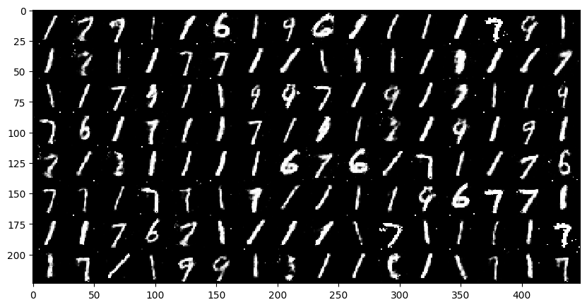

```python
with torch.no_grad():
    z = Variable(Tensor(np.random.normal(0, 1, (128, latent_dim))))
    gen_imgs = generator(z)

img = make_grid(gen_imgs, padding=0, nrow=16)
npimg = (img.cpu().numpy() * 0.5) + 0.5

fig, axes = plt.subplots(1,1, figsize=(10,10))
axes.imshow(np.transpose(npimg, (1,2,0)), interpolation='nearest')
fig.show()
```

# Adjusting the Parameters, such that D has Significantly Fewer than G

```
Downloading http://yann.lecun.com/exdb/mnist/train-images-idx3-ubyte.gz
Downloading http://yann.lecun.com/exdb/mnist/train-images-idx3-ubyte.gz to ./data/MNIST/raw/train-images-idx3-ubyte.gz
```

```
Extracting ./data/MNIST/raw/train-images-idx3-ubyte.gz to ./data/MNIST/raw

Downloading http://yann.lecun.com/exdb/mnist/train-labels-idx1-ubyte.gz
Downloading http://yann.lecun.com/exdb/mnist/train-labels-idx1-ubyte.gz to ./data/MNIST/raw/train-labels-idx1-ubyte.gz
```

```
Extracting ./data/MNIST/raw/train-labels-idx1-ubyte.gz to ./data/MNIST/raw

Downloading http://yann.lecun.com/exdb/mnist/t10k-images-idx3-ubyte.gz
Downloading http://yann.lecun.com/exdb/mnist/t10k-images-idx3-ubyte.gz to ./data/MNIST/raw/t10k-images-idx3-ubyte.gz
```

```
Extracting ./data/MNIST/raw/t10k-images-idx3-ubyte.gz to ./data/MNIST/raw

Downloading http://yann.lecun.com/exdb/mnist/t10k-labels-idx1-ubyte.gz
Downloading http://yann.lecun.com/exdb/mnist/t10k-labels-idx1-ubyte.gz to ./data/MNIST/raw/t10k-labels-idx1-ubyte.gz
```

```
Extracting ./data/MNIST/raw/t10k-labels-idx1-ubyte.gz to ./data/MNIST/raw
```

```
[Epoch 0/200] [Batch 0/938] [D loss: 1.371134] [G loss: 0.696454]
[Epoch 0/200] [Batch 500/938] [D loss: 1.159880] [G loss: 0.967230]
[Epoch 1/200] [Batch 62/938] [D loss: 1.104909] [G loss: 1.007381]
[Epoch 1/200] [Batch 562/938] [D loss: 1.277760] [G loss: 0.483737]
[Epoch 2/200] [Batch 124/938] [D loss: 0.998654] [G loss: 1.010731]
[Epoch 2/200] [Batch 624/938] [D loss: 1.089592] [G loss: 1.156883]
[Epoch 3/200] [Batch 186/938] [D loss: 1.245258] [G loss: 0.746938]
[Epoch 3/200] [Batch 686/938] [D loss: 0.912099] [G loss: 0.955888]
[Epoch 4/200] [Batch 248/938] [D loss: 1.031985] [G loss: 0.943999]
[Epoch 4/200] [Batch 748/938] [D loss: 1.087707] [G loss: 0.680726]
[Epoch 5/200] [Batch 310/938] [D loss: 1.157069] [G loss: 0.959206]
[Epoch 5/200] [Batch 810/938] [D loss: 0.939316] [G loss: 1.000784]
[Epoch 6/200] [Batch 372/938] [D loss: 1.153738] [G loss: 0.628664]
[Epoch 6/200] [Batch 872/938] [D loss: 0.890691] [G loss: 1.168653]
[Epoch 7/200] [Batch 434/938] [D loss: 0.923885] [G loss: 1.006693]
[Epoch 7/200] [Batch 934/938] [D loss: 1.135893] [G loss: 1.045115]
[Epoch 8/200] [Batch 496/938] [D loss: 0.936188] [G loss: 1.199011]
[Epoch 9/200] [Batch 58/938] [D loss: 1.076431] [G loss: 0.974068]
[Epoch 9/200] [Batch 558/938] [D loss: 1.140158] [G loss: 1.112278]
[Epoch 10/200] [Batch 120/938] [D loss: 0.933470] [G loss: 1.050452]
[Epoch 10/200] [Batch 620/938] [D loss: 0.919886] [G loss: 0.826656]
[Epoch 11/200] [Batch 182/938] [D loss: 0.982822] [G loss: 0.967518]
[Epoch 11/200] [Batch 682/938] [D loss: 0.904315] [G loss: 1.523489]
[Epoch 12/200] [Batch 244/938] [D loss: 0.644483] [G loss: 1.668496]
[Epoch 12/200] [Batch 744/938] [D loss: 0.988535] [G loss: 1.038089]
[Epoch 13/200] [Batch 306/938] [D loss: 0.978667] [G loss: 0.790174]
[Epoch 13/200] [Batch 806/938] [D loss: 1.169436] [G loss: 0.802925]
[Epoch 14/200] [Batch 368/938] [D loss: 1.122789] [G loss: 0.777376]
[Epoch 14/200] [Batch 868/938] [D loss: 1.035969] [G loss: 1.147420]
[Epoch 15/200] [Batch 430/938] [D loss: 0.923321] [G loss: 1.017152]
[Epoch 15/200] [Batch 930/938] [D loss: 0.845064] [G loss: 1.247339]
[Epoch 16/200] [Batch 492/938] [D loss: 0.992956] [G loss: 1.203248]
[Epoch 17/200] [Batch 54/938] [D loss: 1.132892] [G loss: 0.592730]
[Epoch 17/200] [Batch 554/938] [D loss: 1.040810] [G loss: 1.098949]
[Epoch 18/200] [Batch 116/938] [D loss: 0.882515] [G loss: 1.109321]
[Epoch 18/200] [Batch 616/938] [D loss: 1.119806] [G loss: 1.937014]
[Epoch 19/200] [Batch 178/938] [D loss: 1.076476] [G loss: 1.537012]
[Epoch 19/200] [Batch 678/938] [D loss: 0.934757] [G loss: 1.364232]
[Epoch 20/200] [Batch 240/938] [D loss: 0.926530] [G loss: 1.491746]
[Epoch 20/200] [Batch 740/938] [D loss: 1.139914] [G loss: 0.858738]
```

[output cut: 321 more lines]

```
[Epoch 192/200] [Batch 404/938] [D loss: 0.470319] [G loss: 2.088001]
[Epoch 192/200] [Batch 904/938] [D loss: 0.746449] [G loss: 2.393546]
[Epoch 193/200] [Batch 466/938] [D loss: 0.885905] [G loss: 1.917754]
[Epoch 194/200] [Batch 28/938] [D loss: 0.435080] [G loss: 2.192530]
[Epoch 194/200] [Batch 528/938] [D loss: 0.576438] [G loss: 2.154432]
[Epoch 195/200] [Batch 90/938] [D loss: 0.544191] [G loss: 2.144041]
[Epoch 195/200] [Batch 590/938] [D loss: 0.728864] [G loss: 3.639968]
[Epoch 196/200] [Batch 152/938] [D loss: 0.525171] [G loss: 2.347605]
[Epoch 196/200] [Batch 652/938] [D loss: 0.644165] [G loss: 2.814271]
[Epoch 197/200] [Batch 214/938] [D loss: 0.572961] [G loss: 2.610572]
[Epoch 197/200] [Batch 714/938] [D loss: 0.530566] [G loss: 2.353548]
[Epoch 198/200] [Batch 276/938] [D loss: 0.382146] [G loss: 2.739206]
[Epoch 198/200] [Batch 776/938] [D loss: 0.505197] [G loss: 2.478022]
[Epoch 199/200] [Batch 338/938] [D loss: 0.571344] [G loss: 1.665280]
[Epoch 199/200] [Batch 838/938] [D loss: 0.436434] [G loss: 2.553908]
```

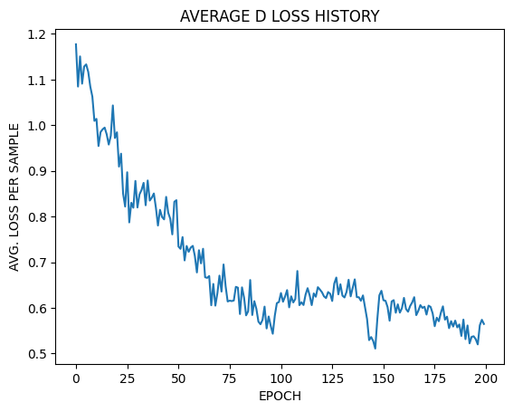

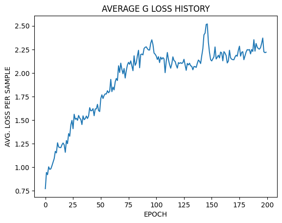

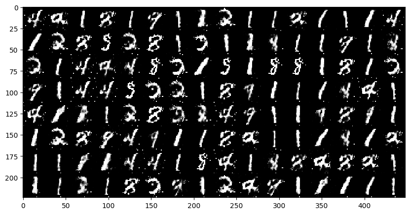

```python
%matplotlib inline
import argparse
import os
import numpy as np
import math
import matplotlib.pyplot as plt

import torchvision.transforms as transforms
from torchvision.utils import save_image
from torchvision import datasets
from torchvision.utils import make_grid

from torch.utils.data import DataLoader
from torch.autograd import Variable
import torch.nn as nn
import torch.nn.functional as F
import torch

os.makedirs("images", exist_ok=True)

n_epochs = 200 # number of epochs of training
batch_size = 64 # size of the batches
n_cpu = 8 # number of cpu threads to use during batch generation

# Adam parameters
lr = 0.0002 # adam: learning rate
b1 = 0.5 # adam: decay of first order momentum of gradient
b2 = 0.999 # adam: decay of first order momentum of gradient

latent_dim = 100 # dimensionality of the latent space
img_size = 28 # size of each image dimension
channels = 1 # number of image channels
sample_interval = 500 # interval betwen image samples
img_shape = (channels, img_size, img_size)

cuda = True if torch.cuda.is_available() else False

class Generator(nn.Module):
    def __init__(self):
        super(Generator, self).__init__()

        def block(in_feat, out_feat, normalize=True):
            layers = [nn.Linear(in_feat, out_feat)]
            if normalize:
                layers.append(nn.BatchNorm1d(out_feat, 0.8))
            layers.append(nn.LeakyReLU(0.2, inplace=True))
            return layers

        self.model = nn.Sequential(
            *block(latent_dim, 128, normalize=False),
            *block(128, 256),
            *block(256, 512),
            *block(512, 1024),
            nn.Linear(1024, int(np.prod(img_shape))),
            nn.Tanh()
        )

    def forward(self, z):
        img = self.model(z)
        img = img.view(img.size(0), *img_shape)
        return img

class Discriminator(nn.Module):
    def __init__(self):
        super(Discriminator, self).__init__()

        self.model = nn.Sequential(
            nn.Linear(int(np.prod(img_shape)), 256),
            nn.LeakyReLU(0.2, inplace=True),
            nn.Linear(256, 128),
            nn.LeakyReLU(0.2, inplace=True),
            nn.Linear(128, 1),
            nn.Sigmoid(),
        )

    def forward(self, img):
        img_flat = img.view(img.size(0), -1)
        validity = self.model(img_flat)

        return validity

# Loss function
adversarial_loss = torch.nn.BCELoss()

# Initialize generator and discriminator
generator = Generator()
discriminator = Discriminator()

if cuda:
    generator.cuda()
    discriminator.cuda()
    adversarial_loss.cuda()

# Configure data loader
os.makedirs("./data", exist_ok=True)
dataloader = torch.utils.data.DataLoader(
    datasets.MNIST(
        "./data",
        train=True,
        download=True,
        transform=transforms.Compose(
            [transforms.ToTensor(), transforms.Normalize([0.5], [0.5])]
        ),
    ),
    batch_size=batch_size,
    shuffle=True,
)

# transform: -1 <= (x - 0.5) / 0.5 <= 1

# Optimizers
optimizer_G = torch.optim.Adam(generator.parameters(), lr=2.0*lr, betas=(b1, b2))
optimizer_D = torch.optim.Adam(discriminator.parameters(), lr=lr, betas=(b1, b2))

Tensor = torch.cuda.FloatTensor if cuda else torch.FloatTensor

# ----------
#  Training
# ----------
avg_d_loss_history = []
avg_g_loss_history = []
for epoch in range(n_epochs):
    avg_d_loss = 0.
    avg_g_loss = 0.
    for i, (imgs, _) in enumerate(dataloader):

        # Adversarial ground truths
        valid = Variable(Tensor(imgs.size(0), 1).fill_(1.0), requires_grad=False)
        fake = Variable(Tensor(imgs.size(0), 1).fill_(0.0), requires_grad=False)

        # Configure input
        real_imgs = Variable(imgs.type(Tensor))

        # -----------------
        #  Train Generator
        # -----------------
        optimizer_G.zero_grad()

        # Sample noise as generator input
        z = Variable(Tensor(np.random.normal(0, 1, (imgs.shape[0], latent_dim))))

        # Generate a batch of images
        gen_imgs = generator(z)

        # Loss measures generator's ability to fool the discriminator
        g_loss = adversarial_loss(discriminator(gen_imgs), valid)

        g_loss.backward()
        optimizer_G.step()

        # ---------------------
        #  Train Discriminator
        # ---------------------
        optimizer_D.zero_grad()

        # Measure discriminator's ability to classify real from generated samples
        real_loss = adversarial_loss(discriminator(real_imgs), valid)
        fake_loss = adversarial_loss(discriminator(gen_imgs.detach()), fake)
        d_loss = (real_loss + fake_loss)

        d_loss.backward()
        optimizer_D.step()

        avg_d_loss += d_loss.item()
        avg_g_loss += g_loss.item()

        batches_done = epoch * len(dataloader) + i
        if batches_done % sample_interval == 0:
            print("[Epoch %d/%d] [Batch %d/%d] [D loss: %f] [G loss: %f]" % (epoch, n_epochs, i, len(dataloader), d_loss.item(), g_loss.item()) )
            save_image(gen_imgs.data[:25], "images/%d.png" % batches_done, nrow=5, normalize=True)

    avg_d_loss /= len(dataloader)
    avg_g_loss /= len(dataloader)
    avg_d_loss_history.append(avg_d_loss)
    avg_g_loss_history.append(avg_g_loss)


plt.plot(avg_d_loss_history)
plt.title("AVERAGE D LOSS HISTORY")
plt.xlabel("EPOCH")
plt.ylabel("AVG. LOSS PER SAMPLE")
plt.show()
plt.plot(avg_g_loss_history)
plt.title("AVERAGE G LOSS HISTORY")
plt.xlabel("EPOCH")
plt.ylabel("AVG. LOSS PER SAMPLE")
plt.show()


with torch.no_grad():
    z = Variable(Tensor(np.random.normal(0, 1, (128, latent_dim))))
    gen_imgs = generator(z)

img = make_grid(gen_imgs, padding=0, nrow=16)
npimg = (img.cpu().numpy() * 0.5) + 0.5

fig, axes = plt.subplots(1,1, figsize=(10,10))
axes.imshow(np.transpose(npimg, (1,2,0)), interpolation='nearest')
fig.show()
```